# Introduction

François HU - ENSAE - *14/04/20* - https://curiousml.github.io/

```python
from jyquickhelper import add_notebook_menu
add_notebook_menu()
```

run previous cell, wait for 2 seconds

**Organisation des parties :**

- **introduction** : définitions et processing + une première approche de vectorisation des données textuelles ($\color{red}{\text{ce notebook}}$)
- **partie 1** : NLP dans un contexte **non-supervisé** (Notebook : $\color{red}{\text{Représentations vectorielles}}$)
- **partie 2** : NLP dans un contexte **supervisé** (Notebook : $\color{red}{\text{Deep Learning pour NLP}}$)
- **partie 3** : NLP dans un contexte **semi-supervisé** (Notebook : $\color{red}{\text{Problèmes d'annotation}}$)

## 1. Quelques prérequis

$\color{grey}{\text{*cacher le code}}$

```python
from IPython.display import HTML, Image
HTML('''<script>code_show=true; function code_toggle() {if (code_show){$('div.input').hide();} else {$('div.input').show();}code_show = !code_show} $( document ).ready(code_toggle);</script><form action="javascript:code_toggle()"><input type="submit" value="cacher / afficher code"></form>''')
```

### Machine learning

- $\color{#228B22}{\text{Machine Learning}}$ (apprentissage machine ou automatique) : la science de programmer les ordinateurs de sorte qu'ils puissent apprendre à partir des données (que nous notons $X$)
- $\color{#228B22}{\text{Apprentissage supervisé}}$ : apprentissage machine où les données d'entraînement sont étiquetées $ \to (X,y)$
  - classification ($\color{#228B22}{\text{régression logistique}}$, $\color{#228B22}{\text{régression softmax}}$, $\dots$),
  - régression, $\dots$
- $\color{#228B22}{\text{Apprentissage non-supervisé}}$ : apprentissage machine où les données d'entraînement **ne** sont **pas** étiquetées $ \to X$
  - partitionnement (ou clustering),
  - réduction de dimensionalité, $\dots$
- phases d'un système de Machine Learning : **phase d'apprentissage**, **phase d'inférence / de prédiction**
- **comment entraîner un modèle ?** créer un modèle prédictif puis régler ses paramètres (souvent minimisation d'une $\color{#228B22}{\text{métrique}}$ par $\color{#228B22}{\text{descente de gradient}}$)

### Deep learning

**Régression logistique**

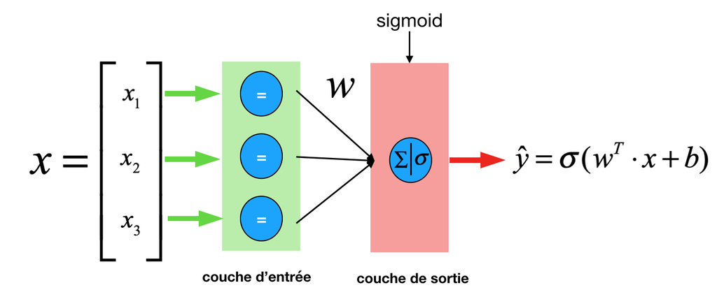

```python
Image("img/logreg.png", width=700, height = 200)
```

**Quelques fonctions d'activation**

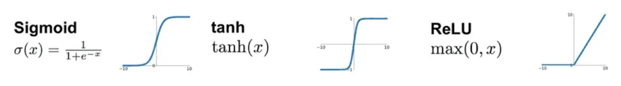

```python
Image("img/factivations.png", width=800, height = 200)
```

**Réseau de neurones**

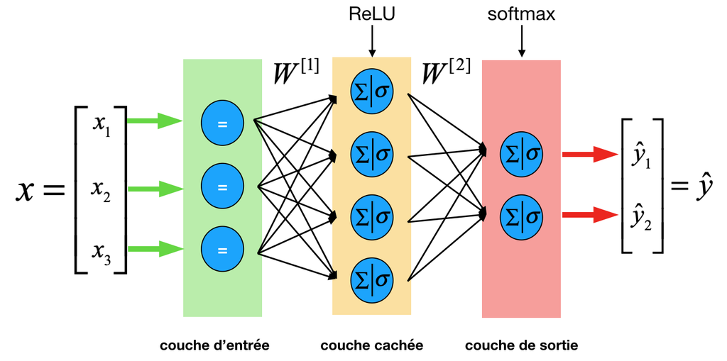

```python
Image("img/RNA.png", width=750, height = 200)
```

**Deep Learning** (apprentissage profond)

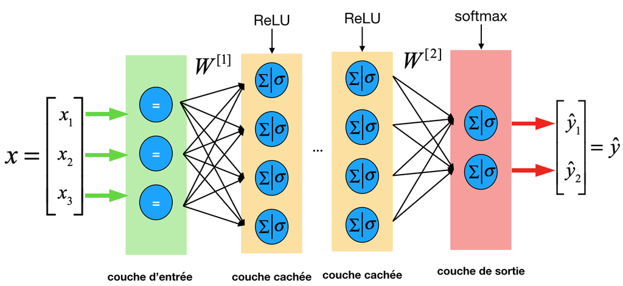

```python
Image("img/DL.png", width=850, height = 200)
```

## 2. Définitions et préprocessing

$\color{grey}{\text{*afficher le code}}$

```python
from IPython.display import HTML, Image
HTML('''<script>code_show=true; function code_toggle() {if (code_show){$('div.input').hide();} else {$('div.input').show();}code_show = !code_show} $( document ).ready(code_toggle);</script><form action="javascript:code_toggle()"><input type="submit" value="cacher / afficher code"></form>''')
```

### Tokenization

- $\color{#228B22}{\text{Texte}}$ : séquence de mots
- $\color{#228B22}{\text{Mot}}$ : séquence logique de caractères
- $\color{#228B22}{\text{Tokenization}}$ : processus qui sépare une séquence (texte) en une liste de tokens (mots)
- **question** : comment trouver les limites d'un mot ? En français / anglais, nous pouvons séparer les mots par les **espaces** et les **ponctuations**
- **input** : `"Devons-nous, mon collègue et moi, vous recontacter?"`
- **output** : `["Devons", "nous", "mon", "collègue", "et", "moi", "vous", "recontacter"]`

```python
from nltk.tokenize import WhitespaceTokenizer, WordPunctTokenizer, word_tokenize
text = "J'ai une question : devons-nous, mon collègue et moi, vous recontacter?"
```

**Implémentations avec python**

- **exemple 1** : tokenization par les espaces

```python
tokenizer = WhitespaceTokenizer()
print(tokenizer.tokenize(text))
```

```
["J'ai", 'une', 'question', ':', 'devons-nous,', 'mon', 'collègue', 'et', 'moi,', 'vous', 'recontacter?']
```

- **exemple 2** : tokenization par les ponctuations

```python
tokenizer = WordPunctTokenizer()
print(tokenizer.tokenize(text))
```

```
['J', "'", 'ai', 'une', 'question', ':', 'devons', '-', 'nous', ',', 'mon', 'collègue', 'et', 'moi', ',', 'vous', 'recontacter', '?']
```

- **exemple 3** : tokenization par un ensemble de règles

```python
print(word_tokenize(text, language='french'))
```

```
["J'ai", 'une', 'question', ':', 'devons-nous', ',', 'mon', 'collègue', 'et', 'moi', ',', 'vous', 'recontacter', '?']
```

### Normalisation des tokens : racinisation et lemmatisation

- $\color{#228B22}{\text{Stemming}}$ : garder la racine d'un terme (souvent, enlever une partie de la fin du terme)
- **exemple** :

continu$\color{red}{\text{a}}$, continu$\color{red}{\text{ait}}$, continu$\color{red}{\text{ant}}$, continu$\color{red}{\text{ation}}$, continu$\color{red}{\text{ation}}$, continu$\color{red}{\text{e}}$ $\to$ continu

- $\color{#228B22}{\text{Lemmatisation}}$ : ramener un terme à sa forme la plus simple (infinitif ou masculin-singulier)
- **exemple** :

continua, continuait, continuant $\to \color{red}{\text{continuer}}$

continuations, continuation $\to \color{red}{\text{continuation}}$

continue $\to \color{red}{\text{continu / continuer}}$ (adjectif / verbe)

**Implémentations avec python**

- **exemple 1** : racinisation (stemming)

```python
from nltk.stem import SnowballStemmer
fr = SnowballStemmer('french')
" ".join(fr.stem(token) for token in word_tokenize(text))
```

```
"j ' ai une question : devon - nous , mon collègu et moi , vous recontact ?"
```

- **exemple 2** : Lemmatisation

```python
import spacy
nlp = spacy.load('fr_core_news_md')
" ".join(token.lemma_ for token in nlp(text))
```

```
'je avoir un question : devoir - nous , mon collègue et moi , vous recontacter ?'
```

### Autres types de normalisation

Les expressions régulières en Python nécessitent d'importer le module natif **re** : https://fr.wikibooks.org/wiki/Programmation_Python/Regex

```python
import re
text_b = ("<b>" + text + "</b>").lower()
print(text_b)
```

```
<b>j'ai une question : devons-nous, mon collègue et moi, vous recontacter?</b>
```

- supprimer les **balises** : `<...> ... </...>`

```python
text_b = re.sub("<.*?>", " ", text_b) # balises <...>
print(text_b)
```

```
 j'ai une question : devons-nous, mon collègue et moi, vous recontacter?
```

- supprimer les **ponctuations** et les grands espaces : `-, !, ?, :, ...`

```python
import string
text_b = re.sub(r"[" + string.punctuation + r"]", " ", text_b) # ponctuations
text_b = re.sub(r"\s+", " ", text_b) # grands espaces
print(text_b)
```

```
 j ai une question devons nous mon collègue et moi vous recontacter
```

### Stop-words

- $\color{#228B22}{\text{Stop-words}}$ : ensemble de mots fréquemment utilisés dans une langue et qui n'apportent pas de signification importante
- **exemple** : `a, à, des, de, et, est, un, ...`

**implémentations avec python : supprimer les stopwords**

```python
from nltk.corpus import stopwords
# Chargement des stopwords pour la langue francaise avec NLTK
stopwords_lst = list(stopwords.words("french"))
re.sub(r"(\s+|^)(" + r"|".join(stopwords_lst) + r")(\s+|$)", " ", text)
```

```
"J'ai question : devons-nous, collègue moi, recontacter?"
```

**Résumé** :

- tokeniser
- raciniser et lemmatiser
- stop-words

## 3. Vectorisation des données textuelles

$\color{grey}{\text{*cacher le code}}$

```python
from IPython.display import HTML, Image
HTML('''<script>code_show=true; function code_toggle() {
            if (code_show){$('div.input').hide();}
            else {$('div.input').show();}code_show = !code_show} $( document ).ready(code_toggle);
        </script><form action="javascript:code_toggle()">
        <input type="submit" value="cacher / afficher code"></form>''')
```

### Données textuelles en données tabulaires

- processus d'apprentissage pour des **données tabulaires** :

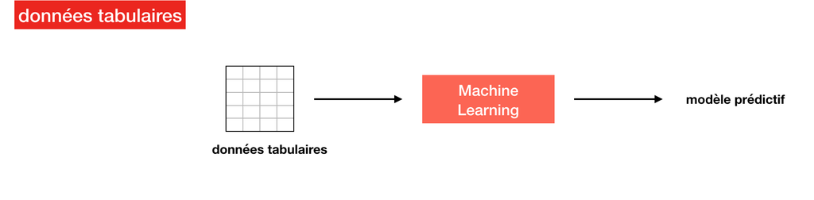

```python
Image("img/MLtab.png", width=600, height = 200)
```

- pour des **données textuelles** :

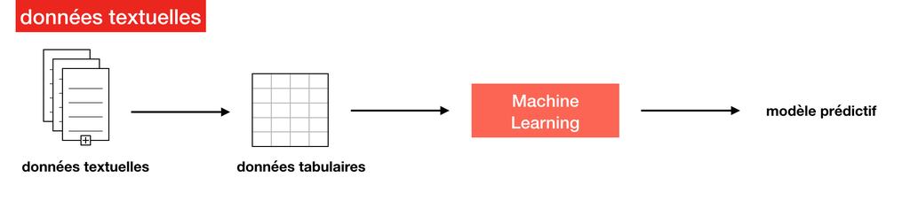

```python
Image("img/MLtext.png", width=600, height = 200)
```

- **approches** : ($\color{red}{\text{section suivante}}$) TF-IDF et ($\color{red}{\text{cours 1}}$) word embedding

### Modèles de vectorisation des textes

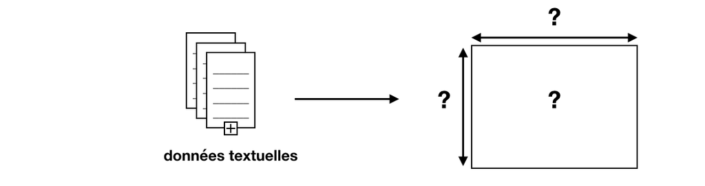

```python
Image("img/tab.png", width=700, height = 200)
```

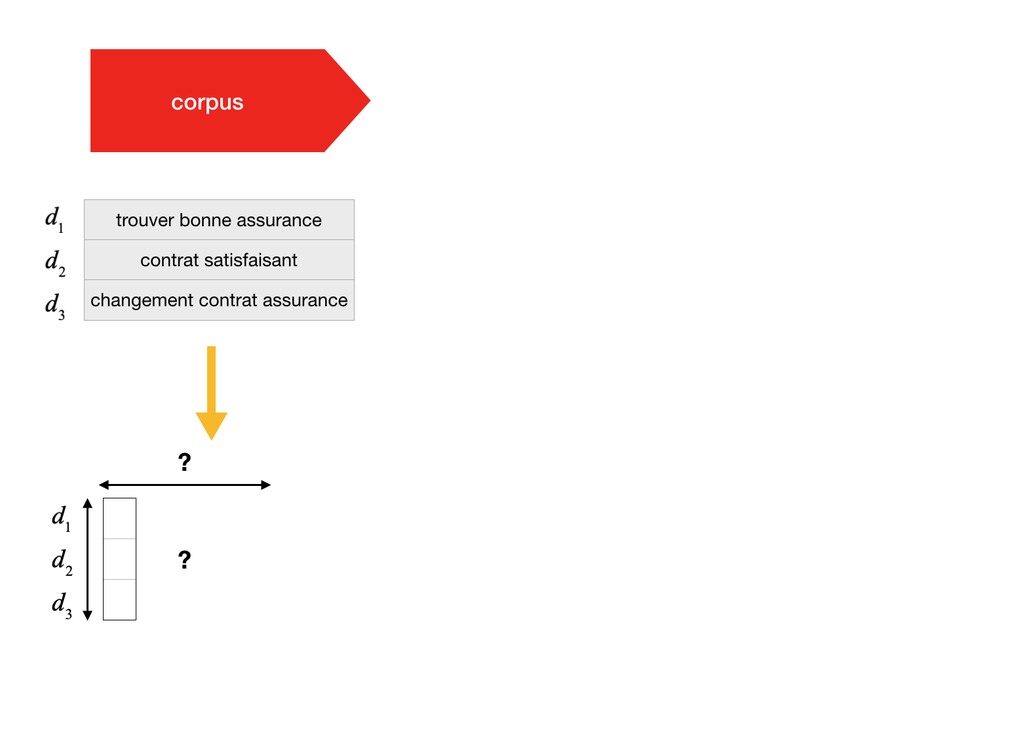

```python
Image("img/BOW1.png", width=800, height = 200)
```

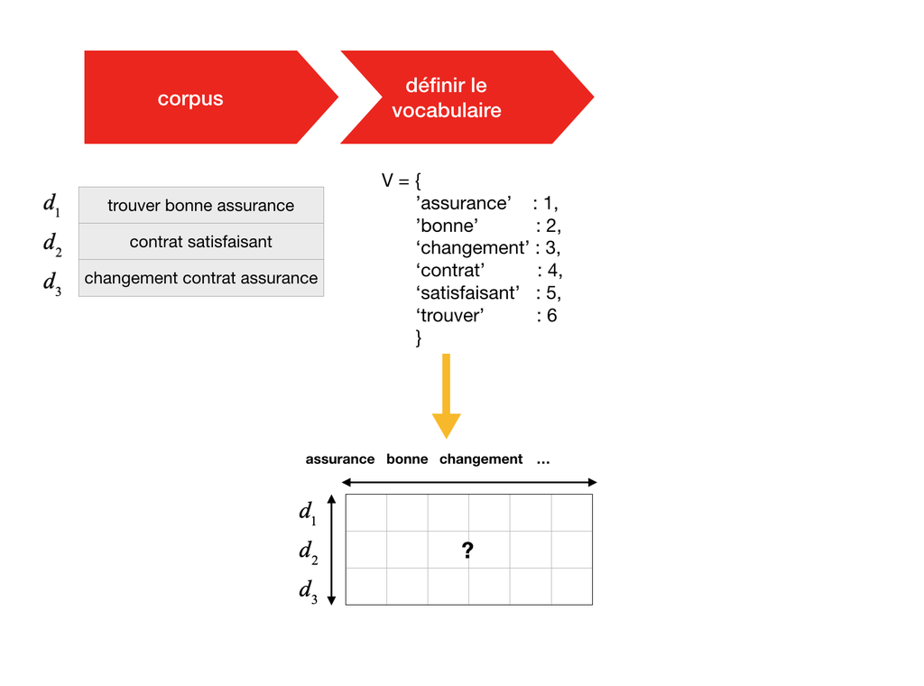

```python
Image("img/BOW2.png", width=800, height = 200)
```

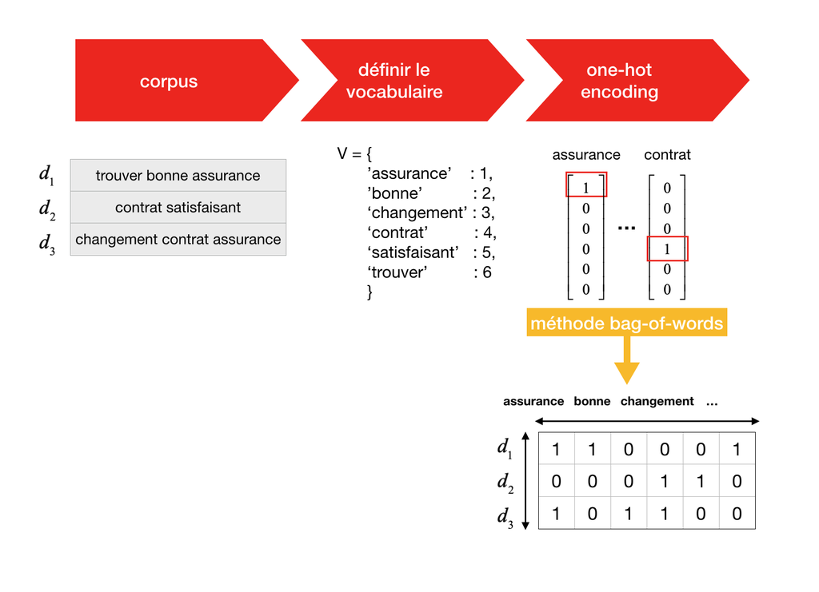

```python
Image("img/BOW3.png", width=800, height = 200)
```

**1. approche bag-of-words**

- vectorise un document en comptant le **nombre d'occurences** d'un token $t$ dans le document $d$ : $f_{t,d}$
- **exemple** : méthode de comptage

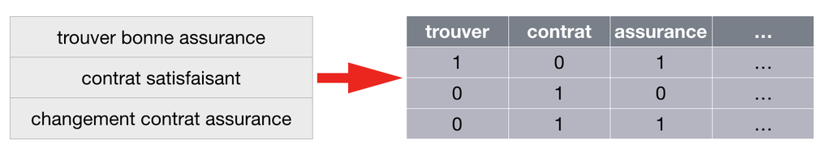

```python
Image("img/BOW_example.png", width=1000, height = 200)
```

- **problème** : pas d'ordre entre les mots
- **solution** : approche n-grammes

**2. approche n-grammes** (n-grams en anglais)

- vectorise un document en comptant le **nombre d'occurences** des paires de tokens (2-grams), des triplets de tokens (3-grams), ...
- **exemple** : méthode de comptage (1,2)-grammes

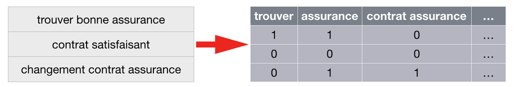

```python
Image("img/ngrams_example.png", width=1000, height = 200)
```

- **problème** : trop de variables
- **solution** : supprimer les stop-words et qq n-grammes (très **hautes** et très **basses** fréquences)

**3. approche TF-IDF**

- $\color{#228B22}{\text{Term Frequency}}$ : nombre d'occurrences d'un token / n-grams $t$ dans le document $d$ $$\text{tf}(t, d) = f_{t,d}$$
- **variantes** : $\frac{f_{t,d}}{\sum\limits_{t'\in d}f_{t',d}}$ ou $\mathbb{1}(t\in d)$ ou $(1 + \log{f_{t,d})}$, ...
- $\color{#228B22}{\text{Inverse Document Frequency}}$ : mesure l'importance du token / n-grams dans l'ensemble du corpus $$\text{idf}(t, D) = \log\frac{|D|}{|\{d \ | \ t\in d\}|} = \log\frac{\text{# documents}}{\text{# documents contenant le terme } t}$$
- $\color{#228B22}{\text{Term Frequency - Inverse Document Frequency (TF-IDF)}}$ : $$\text{tfidf}(t, d, D) = \text{tf}(t, d)\cdot \text{idf}(t, D)$$
- **exemple** : approche TF-IDF (1,2)-grammes

[figure not shown]

```python
Image("img/TFIDF_example.png", width=1000, height = 200)
```

- **implémentations avec python** :

`from sklearn.feature_extraction.text import TfidfVectorizer`

`tfidf = TfidfVectorizer(min_df=2, max_df=0.5, ngram_range=(1,2))`

`features = tfidf.fit_transform(texts)`

- voir **cours 1** pour des techniques de vectorisation plus avancées

**Résumé :**

- méthode 1 : vectorisation par **comptage** + bag-of-words
- méthode 2 : vectorisation par **comptage** + n-grammes
- méthode 3 : vectorisation par TF-IDF